# Introduction to R

Alexandre Courtiol & Liam D. Bailey

# Installing R and RStudio

## What is R?

[figure not shown]

## What is RStudio?

[figure not shown]

## What is RStudio?

[figure not shown]

# R packages

## Installing and loading R packages

```r
install.packages("tidyverse")
```

```r
library(tidyverse)
```

## Packages for this course

**Note**

Please install these on your system now.

```r
# for all kinds of things
install.packages("tidyverse")

# for plotting
install.packages("ggforce")
install.packages("sf")
install.packages("lattice")
install.packages("viridisLite")
install.packages("rnaturalearth")
install.packages("rnaturalearthdata")

# for population genetics
install.packages("adegenet")
install.packages("pegas")
install.packages("poppr")
install.packages("hierfstat")
```

## Updating R packages

```r
packageVersion("poppr")
```

```
[1] '2.9.8'
```

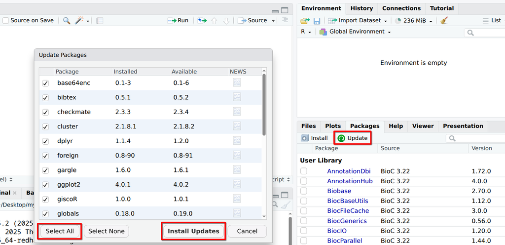

# Good practice

## Good practice

Set RStudio options.

[figure not shown]

## Good practice

Set RStudio options.

[figure not shown]

## Good practice

Use RStudio ‘Projects’ to organize your work.

[figure not shown]

## Good practice

Use RStudio ‘Projects’ to organize your work.

Projects can be directly open from your file explorer.

[figure not shown]

## Good practice

Save your script in a file.

[figure not shown]

**We’ll talk about RMarkdown later**

## Good practice

Use comments to understand your code better.

```r
# EXPLAIN WHY YOU ARE DOING SOMETHING
my_code_here
```

# Basics of R: Functions

## Functions

Functions (generally) take an input and return an output in R.  
For example, the function `sum()` takes a numeric vector and returns a single value.

```r
## Compute the sum of some numbers
sum(c(1, 3, 5, 1))
```

```
[1] 10
```

**Note**

`c()` is itself a function creating the numeric vector.  
We’ll discuss more what a **vector** is soon.

## Functions

Trouble-shoot using `?` or `help()`.

```r
## Help documentation of the function sum()
help(sum)
?sum
```

You can learn what package the function is from, what the function does and what arguments it takes.

## Functions

Trouble-shoot using `?` or `help()`.

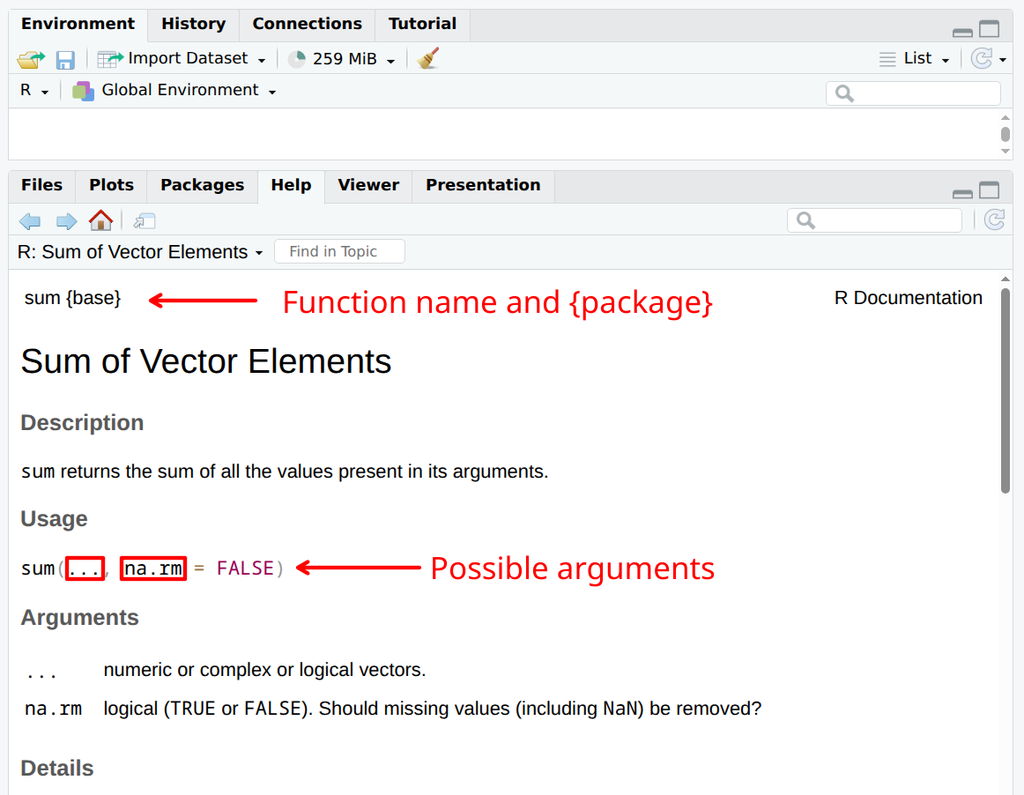

## Functions

**Warning**

Different packages might have functions with the same name. 🤯

Using the syntax `package::function()` makes it explicit which package to use.

```r
## In case of ambiguity, use :: and specify the package
base::sum(c(1, 3, 5, 1))
```

```
[1] 10
```

## Functions

If a function doesn’t work it will display an error…

```r
sum(-)
```

```
Error in parse(text = input): <text>:1:6: unexpected ')'
1: sum(-)
         ^
```

…but these error messages aren’t always easy to understand.

# Basics of R: Objects

## Objects

Basic kinds of R objects (or **classes**):

```r
## Character
"word"
```

```
[1] "word"
```

```r
## Numeric
1.2
```

```
[1] 1.2
```

```r
## Logical
TRUE
```

```
[1] TRUE
```

```r
## Factor
factor(c("A", "B"))
```

```
[1] A B
Levels: A B
```

## Objects

Use `str()` if you’re unsure!

```r
str("word")
```

```
 chr "word"
```

```r
str(1.2)
```

```
 num 1.2
```

```r
str(TRUE)
```

```
 logi TRUE
```

```r
str(factor(c("A", "B")))
```

```
 Factor w/ 2 levels "A","B": 1 2
```

## Objects

Assign an object with `<-` (or `->`).

```r
## Save value to use later!
my_object <- "A"

## Check what object we just created
str(my_object)
```

```
 chr "A"
```

# Vector

## Vector

$\geq$ 1 values of the **same class**.

```r
## Create a vector of numeric
my_vector <- c(1.2, 3.4, 0.1)

## Check the structure...
str(my_vector)
```

```
 num [1:3] 1.2 3.4 0.1
```

## Vector

$\geq$ 1 values of the **same class**.

```r
## A vector *coerces* everything to be the same
my_vector <- c(115.3, -0.1, "2")

## Notice: everything is character!
str(my_vector)
```

```
 chr [1:3] "115.3" "-0.1" "2"
```

## Vector

Vectors have 1 dimension (a length).

```r
## Find how many values are in your vector
length(my_vector)
```

```
[1] 3
```

## Vector

Select particular values using ‘indexing’ with `[]`.

```r
## 'Index' a vector using []
my_vector <- c("A", "B", "C")

## Find the first value in the vector
my_vector[1]
```

```
[1] "A"
```

```r
## Find the first and third value in the vector
my_vector[c(1, 3)]
```

```
[1] "A" "C"
```

```r
## Find everything *except* the second value in the vector
my_vector[-2]
```

```
[1] "A" "C"
```

## Vector

Watch out for missing data.

```r
# This numeric vector has some unusual values
missing_data <- c(NULL, 1.1, 0.2, NA, 7, NaN, Inf)

# NULL: Empty
# NA: Missing data (can be any class)
# NaN: Not a number (specific to numeric)
# Inf: Infinity
str(missing_data)
```

```
 num [1:6] 1.1 0.2 NA 7 NaN ...
```

```r
missing_data
```

```
[1] 1.1 0.2  NA 7.0 NaN Inf
```

# Matrix

## Matrix

$\geq$ 1 value(s) of the **same class** with **two dimensions**.

```r
## Create a 2x2 dimensional matrix
my_matrix <- matrix(c(1, 2, 3, 4),
                    nrow = 2, ncol = 2)
my_matrix
```

```
     [,1] [,2]
[1,]    1    3
[2,]    2    4
```

```r
str(my_matrix)
```

```
 num [1:2, 1:2] 1 2 3 4
```

## Matrix

$\geq$ 1 value(s) of the **same class** with **two dimensions**.

```r
## A matrix will also coerce values!
my_matrix <- matrix(c("1", 2, 3, 4),
                    # Create a 2x2 matrix
                    nrow = 2, ncol = 2)

## Everything is character!
str(my_matrix)
```

```
 chr [1:2, 1:2] "1" "2" "3" "4"
```

## Matrix

$\geq$ 1 value(s) of the **same class** with **two dimensions**.

```r
## Find the number of rows in my matrix
nrow(my_matrix)
```

```
[1] 2
```

```r
## Find the number of columns in my matrix
ncol(my_matrix)
```

```
[1] 2
```

## Matrix

Index a matrix with `[]`.

**Note**

Remember, we have here two dimensions.  
So we index with `[`**ROW**`,` **COLUMN**`]`.

```r
## Find the value at row 1 and column 2
my_matrix[1, 2]
```

```
[1] "3"
```

```r
## Find all values in row 1
my_matrix[1, ]
```

```
[1] "1" "3"
```

```r
## Find all values in column 2
my_matrix[, 2]
```

```
[1] "3" "4"
```

# List

## List

Contains any number of items.

Each item can be a **different class**.

```r
## Storing in a vector or matrix coerces everything to be the same
c(c(1, 2, 3), c("A", "B", "C"), c(3, 4, 5))
```

```
[1] "1" "2" "3" "A" "B" "C" "3" "4" "5"
```

```r
## Use lists to store objects of different classes together
my_list <- list(c(1, 2, 3),
                c("A", "B", "C"),
                c(3, 4, 5))

my_list
```

```
[[1]]
[1] 1 2 3

[[2]]
[1] "A" "B" "C"

[[3]]
[1] 3 4 5
```

## List

Contains any number of items.

Each item can be a **different class**.

```r
## Check the structure
str(my_list)
```

```
List of 3
 $ : num [1:3] 1 2 3
 $ : chr [1:3] "A" "B" "C"
 $ : num [1:3] 3 4 5
```

## List

A list has **one dimension** (length: the number of items in the list).

```r
## Number of items in the list
length(my_list)
```

```
[1] 3
```

## List

We can index a list with `[]` and `[[]]`.

**Warning**

They have slightly different meanings!

```r
## Use `[]` to create a smaller list
## Create a new list with item 1 and 3
my_list[c(1, 3)]
```

```
[[1]]
[1] 1 2 3

[[2]]
[1] 3 4 5
```

```r
## Use `[[]]` to extract items from the list
## Return list item 1
my_list[[1]]
```

```
[1] 1 2 3
```

## List

List-elements can be named.

```r
## Create a named list
my_named_list <- list(first = c(1, 2, 3),
                      second = c("A", "B", "C"),
                      third = c(3, 4, 5))
my_named_list
```

```
$first
[1] 1 2 3

$second
[1] "A" "B" "C"

$third
[1] 3 4 5
```

## List

When list-elements are named, they can be extracted using either `[[]]` or `$`.

```r
## Use `[[]]` to extract the items inside the list
my_named_list[["first"]] # same as my_named_list[[1]]
```

```
[1] 1 2 3
```

```r
## Use `$` to extract the items inside the list
my_named_list$first
```

```
[1] 1 2 3
```

**Note**

If the name is defined via an object, only `[[]]` will do.

```r
## Define the element name indirectly
what_I_want <- "second"
my_named_list[[what_I_want]]
```

```
[1] "A" "B" "C"
```

## List

**Note**

Many advanced functions store their output as a list object.

Remember, you can use `str()` to understand them better.

```r
# These objects have a nice print output
model <- lm(Sepal.Length ~ Sepal.Width, data = iris)
model
```

```
Call:
lm(formula = Sepal.Length ~ Sepal.Width, data = iris)

Coefficients:
(Intercept)  Sepal.Width
     6.5262      -0.2234
```

## List

**Note**

Many advanced functions store their output as a list object.

Remember, you can use `str()` to understand them better.

```r
# Internally, there is a lot more information!
str(model)
```

```
List of 12
 $ coefficients : Named num [1:2] 6.526 -0.223
  ..- attr(*, "names")= chr [1:2] "(Intercept)" "Sepal.Width"
 $ residuals    : Named num [1:150] -0.644 -0.956 -1.111 -1.234 -0.722 ...
  ..- attr(*, "names")= chr [1:150] "1" "2" "3" "4" ...
 $ effects      : Named num [1:150] -71.566 -1.188 -1.081 -1.187 -0.759 ...
  ..- attr(*, "names")= chr [1:150] "(Intercept)" "Sepal.Width" "" "" ...
 $ rank         : int 2
 $ fitted.values: Named num [1:150] 5.74 5.86 5.81 5.83 5.72 ...
  ..- attr(*, "names")= chr [1:150] "1" "2" "3" "4" ...
 $ assign       : int [1:2] 0 1
 $ qr           :List of 5
  ..$ qr   : num [1:150, 1:2] -12.2474 0.0816 0.0816 0.0816 0.0816 ...
  .. ..- attr(*, "dimnames")=List of 2
  .. .. ..$ : chr [1:150] "1" "2" "3" "4" ...
  .. .. ..$ : chr [1:2] "(Intercept)" "Sepal.Width"
  .. ..- attr(*, "assign")= int [1:2] 0 1
  ..$ qraux: num [1:2] 1.08 1.02
  ..$ pivot: int [1:2] 1 2
  ..$ tol  : num 1e-07
  ..$ rank : int 2
  ..- attr(*, "class")= chr "qr"
 $ df.residual  : int 148
 $ xlevels      : Named list()
 $ call         : language lm(formula = Sepal.Length ~ Sepal.Width, data = iris)
 $ terms        :Classes 'terms', 'formula'  language Sepal.Length ~ Sepal.Width
  .. ..- attr(*, "variables")= language list(Sepal.Length, Sepal.Width)
  .. ..- attr(*, "factors")= int [1:2, 1] 0 1
  .. .. ..- attr(*, "dimnames")=List of 2
  .. .. .. ..$ : chr [1:2] "Sepal.Length" "Sepal.Width"
  .. .. .. ..$ : chr "Sepal.Width"
  .. ..- attr(*, "term.labels")= chr "Sepal.Width"
  .. ..- attr(*, "order")= int 1
  .. ..- attr(*, "intercept")= int 1
  .. ..- attr(*, "response")= int 1
  .. ..- attr(*, ".Environment")=<environment: R_GlobalEnv>
  .. ..- attr(*, "predvars")= language list(Sepal.Length, Sepal.Width)
  .. ..- attr(*, "dataClasses")= Named chr [1:2] "numeric" "numeric"
  .. .. ..- attr(*, "names")= chr [1:2] "Sepal.Length" "Sepal.Width"
 $ model        :'data.frame':  150 obs. of  2 variables:
  ..$ Sepal.Length: num [1:150] 5.1 4.9 4.7 4.6 5 5.4 4.6 5 4.4 4.9 ...
  ..$ Sepal.Width : num [1:150] 3.5 3 3.2 3.1 3.6 3.9 3.4 3.4 2.9 3.1 ...
  ..- attr(*, "terms")=Classes 'terms', 'formula'  language Sepal.Length ~ Sepal.Width
  .. .. ..- attr(*, "variables")= language list(Sepal.Length, Sepal.Width)
  .. .. ..- attr(*, "factors")= int [1:2, 1] 0 1
  .. .. .. ..- attr(*, "dimnames")=List of 2
  .. .. .. .. ..$ : chr [1:2] "Sepal.Length" "Sepal.Width"
  .. .. .. .. ..$ : chr "Sepal.Width"
  .. .. ..- attr(*, "term.labels")= chr "Sepal.Width"
  .. .. ..- attr(*, "order")= int 1
  .. .. ..- attr(*, "intercept")= int 1
  .. .. ..- attr(*, "response")= int 1
  .. .. ..- attr(*, ".Environment")=<environment: R_GlobalEnv>
  .. .. ..- attr(*, "predvars")= language list(Sepal.Length, Sepal.Width)
  .. .. ..- attr(*, "dataClasses")= Named chr [1:2] "numeric" "numeric"
  .. .. .. ..- attr(*, "names")= chr [1:2] "Sepal.Length" "Sepal.Width"
 - attr(*, "class")= chr "lm"
```

# Data frame

## Data frame

A special list:

- Each item in the list (i.e. column) is a vector (**same class**).
- All items in the list are the **same length**.
- Each item has a **unique name**.

```r
## Create our own data frame!
my_df <- data.frame(col1 = c(1, 2, 3, 4),
                    col2 = c("A", "B", "C", "D"),
                    col3 = c(3, 4, 5, 6))

my_df
```

```
  col1 col2 col3
1    1    A    3
2    2    B    4
3    3    C    5
4    4    D    6
```

## Data frame

A special list:

- Each item in the list (i.e. column) is a vector (**same class**).
- All items in the list are the **same length**.
- Each item has a **unique name**.

```r
## Check the structure
str(my_df)
```

```
'data.frame':   4 obs. of  3 variables:
 $ col1: num  1 2 3 4
 $ col2: chr  "A" "B" "C" "D"
 $ col3: num  3 4 5 6
```

## Data frame

A data frame has **two dimensions** (number of rows and number of columns).

```r
## Number of rows...
nrow(my_df)
```

```
[1] 4
```

```r
## Number of columns...
ncol(my_df)
```

```
[1] 3
```

## Data frame

We can index using `[]` (just like a matrix) or using column names.

```r
## Items in rows 1 and 2 from column 2
my_df[c(1, 2), 2]
```

```
[1] "A" "B"
```

```r
## All items in column 2
my_df[, 2] # same as my_df[[2]]
```

```
[1] "A" "B" "C" "D"
```

```r
## All items in column 2
my_df[, "col2"] # same as my_df[["col2"]]
```

```
[1] "A" "B" "C" "D"
```

```r
## All items in column named 'col2'
my_df$col2 # but my_df$2 would not work!
```

```
[1] "A" "B" "C" "D"
```

## Data frame

We usually create a data frame by reading in a `.csv` file!

```r
## Items in rows 1 and 2 from column 2
iris_df <- read.csv("iris.csv")

str(iris_df)
```

```
'data.frame':   150 obs. of  5 variables:
 $ Sepal.Length: num  5.1 4.9 4.7 4.6 5 5.4 4.6 5 4.4 4.9 ...
 $ Sepal.Width : num  3.5 3 3.2 3.1 3.6 3.9 3.4 3.4 2.9 3.1 ...
 $ Petal.Length: num  1.4 1.4 1.3 1.5 1.4 1.7 1.4 1.5 1.4 1.5 ...
 $ Petal.Width : num  0.2 0.2 0.2 0.2 0.2 0.4 0.3 0.2 0.2 0.1 ...
 $ Species     : chr  "setosa" "setosa" "setosa" "setosa" ...
```

## Data frame

Use functions `head()`, `tail()`, or `summary()` to investigate a large data frame.

```r
## The first few rows of data...
head(iris_df)
```

```
  Sepal.Length Sepal.Width Petal.Length Petal.Width Species
1          5.1         3.5          1.4         0.2  setosa
2          4.9         3.0          1.4         0.2  setosa
3          4.7         3.2          1.3         0.2  setosa
4          4.6         3.1          1.5         0.2  setosa
5          5.0         3.6          1.4         0.2  setosa
6          5.4         3.9          1.7         0.4  setosa
```

## Data frame

Use functions `head()`, `tail()`, or `summary()` to investigate a large data frame.

```r
## A summary of all the columns
summary(iris_df)
```

```
  Sepal.Length    Sepal.Width     Petal.Length    Petal.Width
 Min.   :4.300   Min.   :2.000   Min.   :1.000   Min.   :0.100
 1st Qu.:5.100   1st Qu.:2.800   1st Qu.:1.600   1st Qu.:0.300
 Median :5.800   Median :3.000   Median :4.350   Median :1.300
 Mean   :5.843   Mean   :3.057   Mean   :3.758   Mean   :1.199
 3rd Qu.:6.400   3rd Qu.:3.300   3rd Qu.:5.100   3rd Qu.:1.800
 Max.   :7.900   Max.   :4.400   Max.   :6.900   Max.   :2.500
   Species
 Length:150
 Class :character
 Mode  :character
```

# Using Pipes

## Pipes

Pipes (`|>`) forward what is before them as first argument to a function after them.

```r
c(1, 2, 3) |> sum()
```

```
[1] 6
```

This is typically useful to make the code of complex data wrangling compact and readable:

```r
emails <- c("john.smith@email.com", "jane-doe@yahoo.com")

emails |>
  str_remove("@.*") |> # note the use of regular expression (regex)
  str_split("\\.|-") |>
  list_transpose() |>
  as.data.frame(col.names = c("firstname", "surname")) -> people

people
```

```
  firstname surname
1      john   smith
2      jane     doe
```

# Using RMarkdown

## Using RMarkdown

RMarkdown (`.Rmd`) file is a great way to record and share your analyses!

[figure not shown]

## Using RMarkdown

Include code and output in the same document.

````markdown
```{r}
## Write your code inside these 'chunks'
c(1, 2, 3, 4)
```
````

```
[1] 1 2 3 4
```

## Using RMarkdown

Include plots to make a report.

````markdown
```{r}
plot(Sepal.Length ~ Sepal.Width, data = iris_df)
```
````

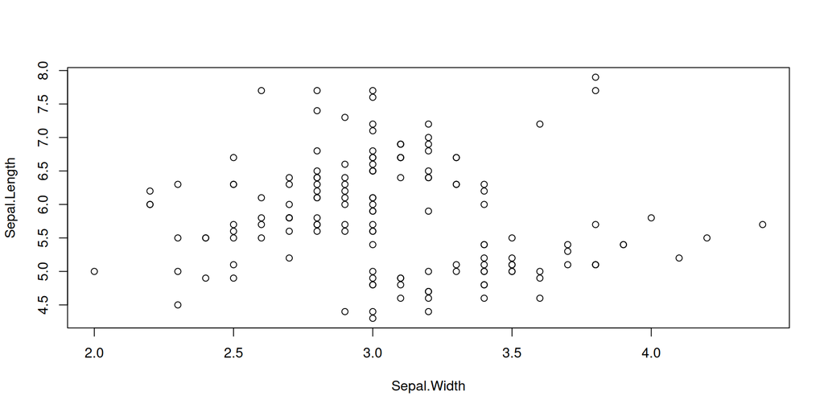

## Using RMarkdown

Write plain text to keep notes.

````markdown
# Section header

## Section subheader

Some notes about my code **in bold**. Below I include my code chunk...

```{r}
1 + 1
```

Some more notes...
````

## Using RMarkdown

‘Knit’ your notes to create a report.

````markdown
# Section header

## Section subheader

Some notes about my code **in bold**. Below I include my code chunk...

```{r}
1 + 1
```

Some more notes...
````

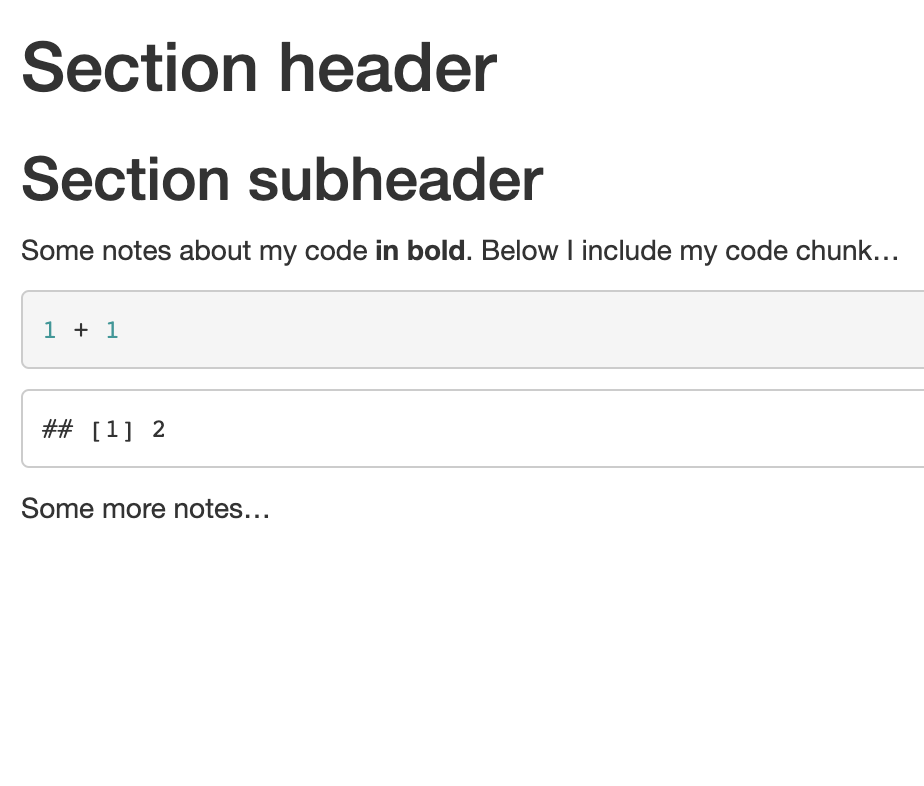

## Using RMarkdown

‘Knit’ your notes to create a report.

[figure not shown]

## Trying out RMarkdown

- Create a new RMarkdown file in RStudio (File > New File > RMarkdown).
- Create a new chunk of R code:

```r
mean(c(1, 2, "3", 4, NA))
```

- Knit the document to html.
- Check the document.  
  Does the code work properly? Can you work out why?
- **BONUS**:
  - Search for the RMarkdown Cheatsheet online and try adding some headers and bold text.
  - Knit the document to PDF.